# Combining Ability: ANOVA and GCA/SCA Effects

- Show All Code
- Hide All Code
- View Source

Analysis 3 of the PUE hybrid series — line × tester (NC Design II) fixed-effects ANOVA and combining-ability effects across five environments

Author

Fausto Rodriguez Zapata

Published

July 6, 2026

**Paper series — notebook 3.** Shared data preparation: `R/prep_traits.R`.

# 1 Methods (for the paper)

Combining ability was analysed with the **line × tester (North Carolina Design II)** model across the five environments. For each of the 11 phenotypes the fixed-effects combined analysis of variance partitions the among-hybrid variation into **general combining ability of the lines** (females, GCA_L), **of the testers** (males, GCA_T), and **specific combining ability** (line × tester, SCA), each with its environment interaction:

$$y = \mu + E + R_{(E)} + \underbrace{L}_{\text{GCA}_L} + \underbrace{T}_{\text{GCA}_T}
+ \underbrace{L{:}T}_{\text{SCA}} + E{:}L + E{:}T + E{:}L{:}T + \varepsilon.$$

**F-tests use the correct strata for a multi-environment trial:** GCA_L, GCA_T and SCA are tested over their respective **environment-interaction** mean squares (not plot error, which would be anticonservative because each combining-ability mean averages over hundreds of plots), and the interaction terms are tested over the residual. **GCA effects** (superior parental lines) and **SCA effects** (superior specific hybrids) are estimated arithmetically from the balanced cross means: $\widehat{\text{GCA}}_i = \bar{x}_{i\cdot} - \bar{x}_{\cdot\cdot}$, $\widehat{\text{SCA}}_{ij} = \bar{x}_{ij} - \bar{x}_{i\cdot} - \bar{x}_{\cdot j} + \bar{x}_{\cdot\cdot}$.

Across-environment PUE averages the optimal and P-stress environments (different applied-P denominators), so PUE combining ability here is a multi-environment blend; see notebook 2 for the within-Chokwe P contrast.

```r
library(tidyverse)
library(knitr)
library(kableExtra)

source("R/prep_traits.R")   # hybrids, trait_meta, analysis_traits
```

# 2 Combined line × tester ANOVA

```r
# Combined LxT ANOVA per trait; returns p-values with the correct error strata.
lt_anova <- function(tn, d) {
  d  <- d %>% mutate(y = .data[[tn]]) %>% filter(!is.na(y))
  m  <- lm(y ~ env + env:rep + female + male + female:male +
               env:female + env:male + env:female:male, data = d)
  a  <- anova(m)
  MS <- setNames(a[["Mean Sq"]], rownames(a))
  DF <- setNames(a[["Df"]],      rownames(a))
  Ft <- function(num, den) {
    f <- MS[[num]] / MS[[den]]
    pf(f, DF[[num]], DF[[den]], lower.tail = FALSE)
  }
  tibble(
    trait     = tn,
    `GCA_L`   = Ft("female", "env:female"),
    `GCA_T`   = Ft("male",   "env:male"),
    `SCA`     = Ft("female:male", "env:female:male"),
    `GCA_L×E` = Ft("env:female", "Residuals"),
    `GCA_T×E` = Ft("env:male",   "Residuals"),
    `SCA×E`   = Ft("env:female:male", "Residuals")
  )
}

stars <- function(p) case_when(is.na(p) ~ "", p < .001 ~ "***", p < .01 ~ "**",
                               p < .05 ~ "*", p < .1 ~ ".", TRUE ~ "ns")

anova_tab <- map_dfr(analysis_traits, lt_anova, d = hybrids) %>%
  left_join(trait_meta, by = "trait") %>% arrange(trait)

anova_tab %>%
  transmute(Group = group, Trait = trait,
            GCA_L = paste0(signif(GCA_L,2), stars(GCA_L)),
            GCA_T = paste0(signif(GCA_T,2), stars(GCA_T)),
            SCA   = paste0(signif(SCA,2),   stars(SCA)),
            `GCA_L×E` = paste0(signif(`GCA_L×E`,2), stars(`GCA_L×E`)),
            `GCA_T×E` = paste0(signif(`GCA_T×E`,2), stars(`GCA_T×E`)),
            `SCA×E`   = paste0(signif(`SCA×E`,2),   stars(`SCA×E`))) %>%
  kable(caption = "Combined line × tester ANOVA: p-values (with significance) per source. GCA_L/GCA_T/SCA are tested over their environment-interaction strata; the ×E terms over residual. *** <.001, ** <.01, * <.05, . <.1, ns ≥ .1.") %>%
  kable_styling(bootstrap_options = c("striped","hover","condensed"), full_width = FALSE) %>%
  collapse_rows(columns = 1, valign = "top")
```

Combined line × tester ANOVA: p-values (with significance) per source. GCA_L/GCA_T/SCA are tested over their environment-interaction strata; the ×E terms over residual. *** <.001, ** <.01, * <.05, . <.1, ns ≥ .1.

| Group | Trait | GCA_L | GCA_T | SCA | GCA_L×E | GCA_T×E | SCA×E |
| --- | --- | --- | --- | --- | --- | --- | --- |
| C – Auxiliary | ASI | 0.83ns | 0.19ns | 0.2ns | 0.062. | 0.83ns | 0.71ns |
|  | DTA | 0.00057*** | 7.5e-05*** | 0.21ns | 0.42ns | 0.87ns | 0.22ns |
|  | DTS | 0.0048** | 1.8e-05*** | 0.19ns | 0.22ns | 0.91ns | 0.25ns |
| A – Selection | GY | 0.13ns | 0.89ns | 0.027* | 0.0047** | 0.43ns | 0.84ns |
| B – Physiological | HI | 0.0095** | 0.13ns | 0.08. | 0.9ns | 0.84ns | 0.75ns |
| C – Auxiliary | PH | 0.047* | 0.2ns | 0.37ns | 0.025* | 0.28ns | 0.026* |
| A – Selection | PUE | 0.41ns | 0.85ns | 0.084. | 4.5e-05*** | 0.51ns | 0.38ns |
| B – Physiological | RSR | 0.43ns | 0.75ns | 0.055. | 0.38ns | 0.41ns | 0.98ns |
|  | RW | 0.0092** | 0.0015** | 0.00058*** | 0.82ns | 0.99ns | 0.95ns |
|  | SW | 0.21ns | 0.064. | 0.081. | 0.06. | 0.033* | 0.25ns |
|  | TDM | 0.1ns | 0.026* | 0.036* | 0.1ns | 0.087. | 0.27ns |

# 3 GCA and SCA effect estimates

```r
# Balanced cross means across env & rep, then arithmetic GCA/SCA per trait.
cross_mean <- hybrids %>%
  group_by(female, male) %>%
  summarise(across(all_of(analysis_traits), ~ mean(.x, na.rm = TRUE)), .groups = "drop")

gca_of <- function(tn) {
  w  <- cross_mean %>% select(female, male, val = all_of(tn))
  gm <- mean(w$val)
  fem <- w %>% group_by(parent = female) %>% summarise(GCA = mean(val) - gm, .groups="drop") %>% mutate(type = "Female (line)")
  mal <- w %>% group_by(parent = male)   %>% summarise(GCA = mean(val) - gm, .groups="drop") %>% mutate(type = "Male (tester)")
  bind_rows(fem, mal) %>% mutate(trait = tn)
}
gca_all <- map_dfr(analysis_traits, gca_of)

sca_of <- function(tn) {
  w  <- cross_mean %>% select(female, male, val = all_of(tn))
  gm <- mean(w$val)
  w %>% group_by(female) %>% mutate(fm = mean(val)) %>%
        group_by(male)   %>% mutate(mm = mean(val)) %>% ungroup() %>%
        mutate(SCA = val - fm - mm + gm, trait = tn)
}
sca_all <- map_dfr(analysis_traits, sca_of)
```

## 3.1 GCA of the female lines (CIMMYT donors)

```r
gca_all %>% filter(type == "Female (line)") %>%
  mutate(trait = factor(trait, levels = analysis_traits)) %>%
  select(parent, trait, GCA) %>%
  pivot_wider(names_from = trait, values_from = GCA) %>%
  mutate(across(-parent, ~ round(.x, 3))) %>%
  rename(`Female line` = parent) %>%
  kable(caption = "General combining ability (GCA) of the 7 CIMMYT female lines, per trait (deviation from the grand mean). Positive = above-average general contribution.") %>%
  kable_styling(bootstrap_options = c("striped","hover","condensed"), full_width = FALSE)
```

General combining ability (GCA) of the 7 CIMMYT female lines, per trait (deviation from the grand mean). Positive = above-average general contribution.

| Female line | GY | PUE | HI | RSR | RW | SW | TDM | PH | DTA | DTS | ASI |
| --- | --- | --- | --- | --- | --- | --- | --- | --- | --- | --- | --- |
| CML364 | -0.085 | -7.006 | -0.002 | -0.002 | -0.498 | -1.996 | -2.494 | 3.577 | 0.721 | 0.550 | -0.171 |
| CML366 | -0.137 | -6.884 | -0.007 | -0.001 | -0.511 | 0.742 | 0.230 | 1.259 | 0.216 | 0.264 | 0.048 |
| CML434 | 0.295 | 7.040 | 0.014 | 0.002 | 0.643 | 2.603 | 3.246 | 3.097 | -0.174 | -0.079 | 0.095 |
| CML435 | -0.198 | -14.211 | 0.012 | -0.005 | -2.744 | -16.397 | -19.141 | -4.674 | -0.612 | -0.527 | 0.086 |
| CML439 | -0.312 | -17.792 | -0.009 | -0.003 | -1.396 | -5.018 | -6.414 | -4.693 | -1.127 | -1.241 | -0.114 |
| CML530 | 0.578 | 39.042 | 0.018 | 0.008 | 3.386 | 10.026 | 13.412 | 4.345 | -0.212 | -0.050 | 0.162 |
| CML532 | -0.142 | -0.189 | -0.026 | 0.000 | 1.120 | 10.041 | 11.161 | -2.912 | 1.188 | 1.083 | -0.105 |

## 3.2 GCA of the male testers (IIAM donors)

```r
gca_all %>% filter(type == "Male (tester)") %>%
  mutate(trait = factor(trait, levels = analysis_traits)) %>%
  select(parent, trait, GCA) %>%
  pivot_wider(names_from = trait, values_from = GCA) %>%
  mutate(across(-parent, ~ round(.x, 3))) %>%
  rename(`Male tester` = parent) %>%
  kable(caption = "GCA of the 7 IIAM male testers, per trait. Near-zero values (esp. for GY and yield components) reflect the near-null tester differentiation established in the earlier notebooks.") %>%
  kable_styling(bootstrap_options = c("striped","hover","condensed"), full_width = FALSE)
```

| Male tester | GY | PUE | HI | RSR | RW | SW | TDM | PH | DTA | DTS | ASI |
| --- | --- | --- | --- | --- | --- | --- | --- | --- | --- | --- | --- |
| EN17 | -0.025 | -7.019 | -0.003 | 0.000 | 0.081 | 0.116 | 0.197 | -0.036 | 0.397 | 0.550 | 0.152 |
| EN20 | 0.113 | 8.021 | -0.003 | -0.002 | 0.173 | 6.450 | 6.623 | -0.842 | -0.307 | -0.193 | 0.114 |
| EN21 | -0.034 | 2.080 | -0.004 | -0.001 | 0.273 | 2.112 | 2.385 | 3.593 | 0.159 | 0.273 | 0.114 |
| EN25 | 0.057 | 10.549 | -0.021 | 0.007 | 3.630 | 19.297 | 22.927 | 2.736 | 1.254 | 1.331 | 0.076 |
| EN31 | -0.078 | -2.789 | 0.009 | -0.002 | -0.993 | -7.193 | -8.187 | 0.450 | -0.707 | -0.993 | -0.286 |
| EN32 | -0.160 | -8.768 | 0.013 | 0.000 | -2.259 | -18.652 | -20.911 | -3.817 | -0.946 | -0.946 | 0.000 |
| EN64 | 0.126 | -2.074 | 0.009 | -0.002 | -0.904 | -2.130 | -3.034 | -2.084 | 0.150 | -0.022 | -0.171 |

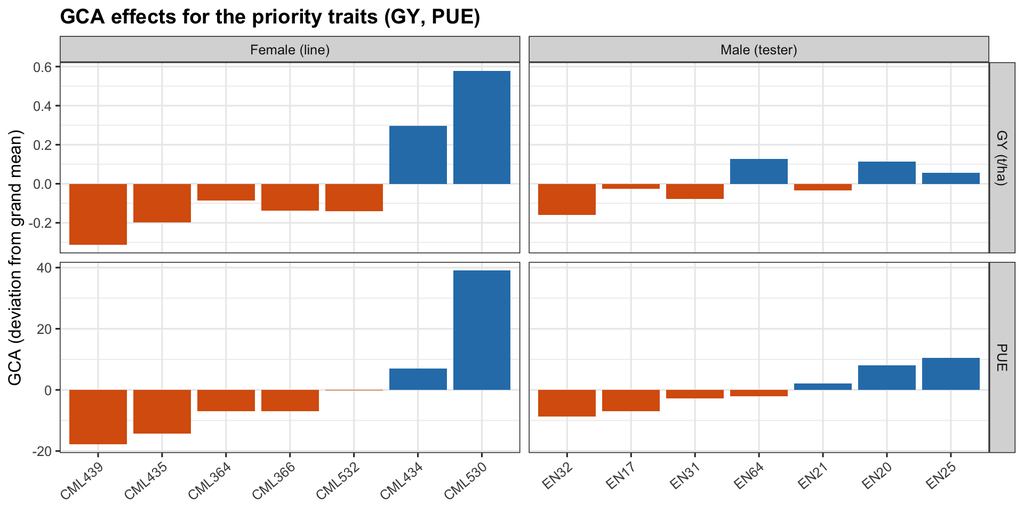

```r
gca_all %>% filter(trait %in% c("GY","PUE")) %>%
  mutate(trait = recode(trait, GY = "GY (t/ha)", PUE = "PUE"),
         parent = reorder(parent, GCA)) %>%
  ggplot(aes(x = parent, y = GCA, fill = GCA > 0)) +
  geom_col() +
  facet_grid(trait ~ type, scales = "free", space = "free_x") +
  scale_fill_manual(values = c(`TRUE` = "#2c7fb8", `FALSE` = "#d95f0e"), guide = "none") +
  labs(title = "GCA effects for the priority traits (GY, PUE)", x = NULL, y = "GCA (deviation from grand mean)") +
  theme_bw(base_size = 12) +
  theme(plot.title = element_text(face = "bold"),
        axis.text.x = element_text(angle = 40, hjust = 1))
```

# 4 Superior hybrids for the priority traits

```r
top_ct <- map_dfr(c("GY", "PUE"), function(tn) {
  sca_all %>% filter(trait == tn) %>%
    arrange(desc(val)) %>% head(8) %>%
    transmute(Trait = tn, Hybrid = paste0(female, " × ", male),
              `Cross mean` = round(val, 3), SCA = round(SCA, 3))
})

kable(top_ct, caption = "Top 8 hybrids for the priority traits (cross mean across environments) with their SCA deviation.") %>%
  kable_styling(bootstrap_options = c("striped", "hover", "condensed"), full_width = FALSE) %>%
  collapse_rows(columns = 1, valign = "top")
```

Top 8 hybrids for the priority traits (cross mean across environments) with their SCA deviation.

| Trait | Hybrid | Cross mean | SCA |
| --- | --- | --- | --- |
| GY | CML530 × EN64 | 8.404 | 1.187 |
|  | CML532 × EN32 | 7.369 | 1.157 |
|  | CML434 × EN20 | 7.219 | 0.298 |
|  | CML530 × EN25 | 7.187 | 0.039 |
|  | CML530 × EN32 | 7.127 | 0.196 |
|  | CML364 × EN21 | 7.059 | 0.665 |
|  | CML366 × EN17 | 6.990 | 0.639 |
|  | CML530 × EN17 | 6.956 | -0.110 |
| PUE | CML530 × EN25 | 531.200 | 39.371 |
|  | CML530 × EN64 | 530.480 | 51.274 |
|  | CML532 × EN32 | 510.573 | 77.291 |
|  | CML434 × EN20 | 503.147 | 45.848 |
|  | CML530 × EN32 | 488.520 | 16.008 |
|  | CML364 × EN21 | 486.733 | 49.421 |
|  | CML366 × EN20 | 475.533 | 32.158 |
|  | CML530 × EN17 | 475.013 | 0.752 |

# 5 Summary